# Diving deep: gradient fluctuations

Date: Oct 18th, 2020

Table of contents:

- Setting up
- Increasing std
- Decreasing std, ways to mitigate vanishing
- Increasing mean

So here, we will see how and when gradient vanishing happen, and also discuss ways to mitigate them. This post should be short and simple.

## Setting up

```python
import torch
import numpy as np
import matplotlib.pyplot as plt
```

Here, we have a function that generates normal distributions and multiply all of them together. For each time that we multiply, we then record both the means and stds, so the function returns 2 1d-arrays:

```python
def generate(mean, std, n=60):
    answer = torch.ones(10000); means = []; stds = []
    for i in range(n):
        answer *= torch.normal(mean, std, (10000,))
        means.append(answer.mean()); stds.append(answer.std())
    return means, stds
```

And this is to analyze a particular means and stds config. This just generate means and stds 10 times, and graph them so we know how they should normally behave. Then 1 particular sample is returned so we can see the general trend:

```python
def stats(tensor): return tensor.mean(), tensor.std()
def tensorListToList(array): return [np.round(tensor.numpy(), 7) for tensor in array]
def analyze(mean, std, meansLimit=None, stdsLimit=None):
    mss, sss = [], []
    for i in range(10):
        ms, ss = generate(mean, std)
        mss.append(ms); sss.append(ss)
    plt.figure(figsize=(10, 3), dpi=100)
    plt.subplot(1, 2, 1); [plt.plot(ms) for ms in mss]; plt.title("Means"); plt.ylim(meansLimit) if meansLimit != None else 0
    plt.subplot(1, 2, 2); [plt.plot(ss) for ss in sss]; plt.title("Stds"); plt.ylim(stdsLimit) if stdsLimit != None else 0
    ms, ss = generate(mean, std)
    return tensorListToList(ms[::10]), tensorListToList(ss[::10])
```

Let's see this in action in the default case of $(0, 1)$:

```
([0.004726, 0.0126579, 0.0006867, 0.0005367, 3.8e-06, 3.5e-06],
 [0.9986122, 0.8883221, 0.0660638, 0.05001, 0.0004166, 0.0003388])
```

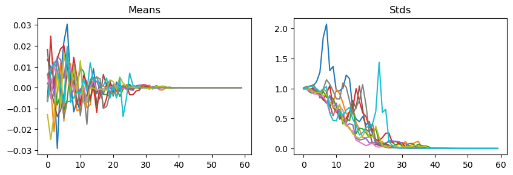

```python
analyze(0, 1)
```

So this is the "ideal" behavior from the literature. Every tensors are normalized to $(0, 1)$, and in theory the standard deviation has to be stable over time. But turns out, it still decays, albeit slowly.

## Increasing std

A natural thought might be increasing the standard deviation by a little bit, to may be 2?

```
([0.0095322, -17.631884, -300.59048, 310314.2, 9175759.0, 166745020.0],
 [1.9897563, 1617.3905, 127801.805, 20253316.0, 1017396700.0, 23813517000.0])
```

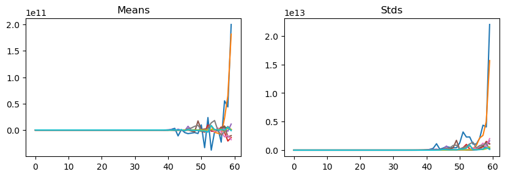

```python
analyze(0, 2)
```

```
([0.0017371, -0.427477, 2.1624246, 5.883277, -112.252625, 1299.6624],
 [1.490578, 37.923653, 579.9135, 9879.253, 11245.935, 124914.44])
```

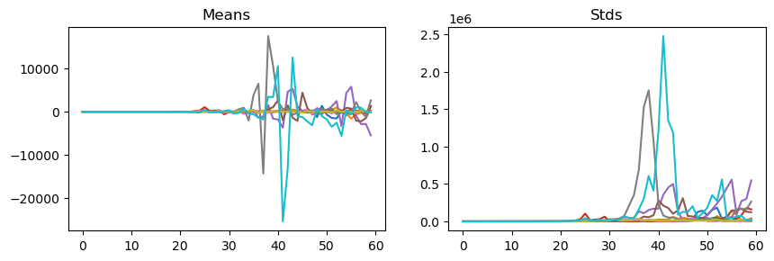

```python
analyze(0, 1.5)
```

This is still quite unstable as a neural net with any $10^6$ weights or activations are screwed.

```
(([-0.0030959, -0.0162459, -0.1905757, 0.1055798, -0.0022609, 0.0008708],
  [1.2028304, 5.366212, 17.05924, 8.938676, 0.2515804, 0.0668345]),
 ([0.008258, -0.0589207, -0.0133605, 0.0022202, -0.0004418, -1e-07],
  [1.1051639, 2.4711137, 0.7671497, 0.1446666, 0.0292719, 0.0005711]))
```

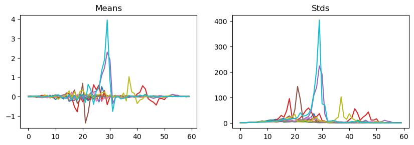

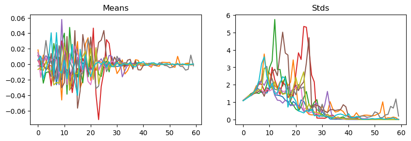

```python
analyze(0, 1.2), analyze(0, 1.1)
```

## Decreasing std, ways to mitigate vanishing

```
(([0.0011083, 0.0025329, -0.0001738, 5.1e-06, 0.0, 0.0],
  [0.907491, 0.3374758, 0.0128589, 0.0015061, 4.5e-06, 1e-07]),
 ([-0.008414, -0.0011584, 1.96e-05, 3e-07, 0.0, 0.0],
  [0.8101226, 0.1005627, 0.0012118, 1.4e-05, 2e-07, 0.0]))
```

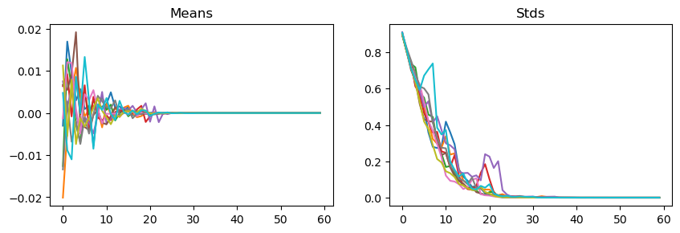

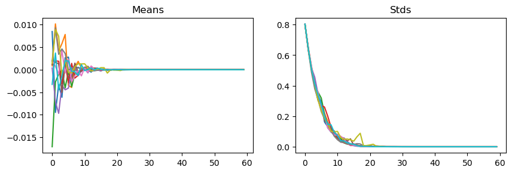

```python
analyze(0, 0.9), analyze(0, 0.8)
```

Oh no, not good. $(0, 0.8)$ basically goes to nothing after only 10 layers. This is worrying, and exactly why it was hard to train deep CNNs back in the AlexNet days. Why am I analyzing $(0, 0.8)$? Because in the industry, that's the best neural nets can behave.

So after passing through 1 linear layer, the activations follow the above analysis of $(0, 1)$, if you initialize them correctly. But you have to then pass that through an activation function, or all those linear transformation afterwards become meaningless. So let's test it out:

```python
def relu(tensor): return (tensor > 0) * tensor
x = torch.normal(0, 1, (10000,)); stats(x), stats(relu(x))
```

```
((tensor(0.0035), tensor(1.0045)), (tensor(0.4015), tensor(0.5941)))
```

Now our std is not 1, but is far less than that, at 0.6. [Kaiming He](https://arxiv.org/pdf/1502.01852.pdf) sort of disgrees with our fate, and decided to put a $\sqrt2$ in front:

```python
stats(relu(x) * np.sqrt(2))
```

```
(tensor(0.5678), tensor(0.8402))
```

## Increasing mean

Let's tweak the mean a little bit, just for curiosity sake:

```
(([0.477026, -0.0864195, 0.0121777, -0.0012479, 8.02e-05, -9.33e-05],
  [1.0034102, 13.394275, 1.1058192, 0.2778655, 0.0849103, 0.0056078]),
 ([0.6012863, -0.0344355, -0.0550536, -0.036129, 0.0009148, 1.11e-05],
  [0.9991372, 3.7942245, 8.531518, 3.12163, 0.2148822, 0.008277]),
 ([0.6804134, 0.0069895, -0.0397755, 0.1368064, -0.1559509, -0.1466025],
  [0.9966327, 5.7475286, 9.293692, 13.099258, 15.007835, 14.94821]))
```

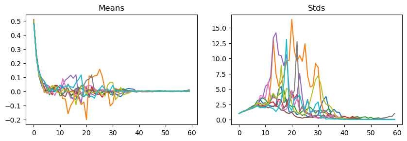

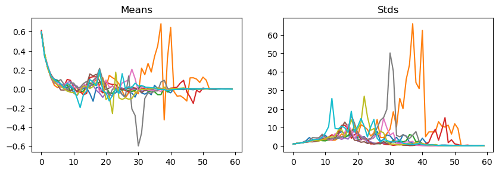

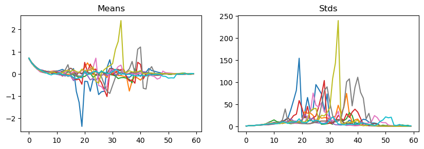

```python
analyze(0.5, 1), analyze(0.6, 1), analyze(0.7, 1)
```

Increasing mean to around 0.5 to 0.6 is sort of okay, but increasing it further will start to make the network unstable.

```
(([1.4992676, 87.548, 5004.954, -1906214.9, 64492304.0, -2086105700.0],
  [0.9993644,
   577.37415,
   253857.61,
   153094770.0,
   6751010300.0,
   355184870000.0]),
 ([0.9976493, 1.0148268, 1.0315311, 1.0374521, 0.9812232, 0.989132],
  [0.3010534, 1.3230047, 2.2125, 3.2678869, 4.0571237, 6.2263236]))
```

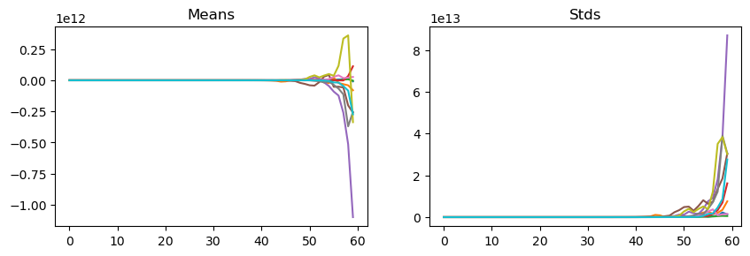

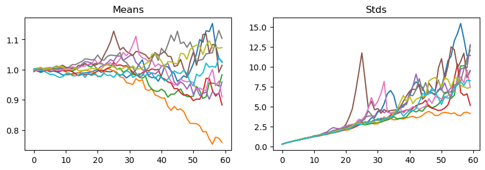

```python
analyze(1.5, 1), analyze(1, 0.3)
```

The above 2 graphs is meant to demosntrate that the mean doesn't need to increase that much to completely wreck your network. Another surprising fact I might add, is by toning down std, we can still keep values under control, but up until a point only. $(1.5, 0.0001)$ will still blow up as usual.

Lastly, negative mean seems to act the same as positive mean. This is understandable, as only signs were flipped, not the tensor scale themselves:

```
([-0.4896994, 0.0282136, -0.0082183, 0.0027812, -6.16e-05, -0.0010862],
 [0.9956397, 2.7155051, 5.6108146, 2.251837, 0.0561705, 0.0978187])
```

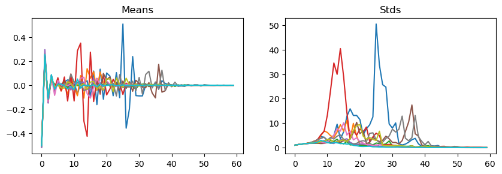

```python
analyze(-0.5, 1)
```